# Assignment 03 - Web Scraping and Text Mining

## Test_mining_1

```r
# Read in dataset
library (data.table)

library(leaflet)
library(tidyverse)
library(lubridate)
```

```r
library(tidytext)
library(ggplot2)


download.file("https://raw.githubusercontent.com/USCbiostats/data-science-data/master/03_pubmed/pubmed.csv", "pubmed.csv", method="libcurl", timeout = 60)
pubmed <- data.table::fread("pubmed.csv")
```

```r
head(pubmed)
```

[output not shown]

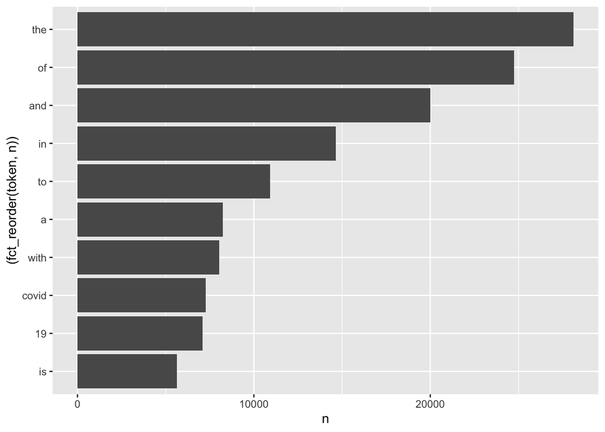

```r
pubmed %>%
  unnest_tokens(output = token, input = abstract) %>%
  count(token, sort = TRUE) %>%
  top_n(10, n) %>%
  ggplot(aes(x=n, y=(fct_reorder(token, n)))) +
  geom_col()
```

- In the initial tokenize, I see that stop words overtook the top 5 of most appeared. With “the” and “of” appearing the most and “covid,” “19” and “is” at the bottom of the top 10. The interesting part is that the word “covid” and “19” do not always appear together, “covid” appear slightly more than “19.”

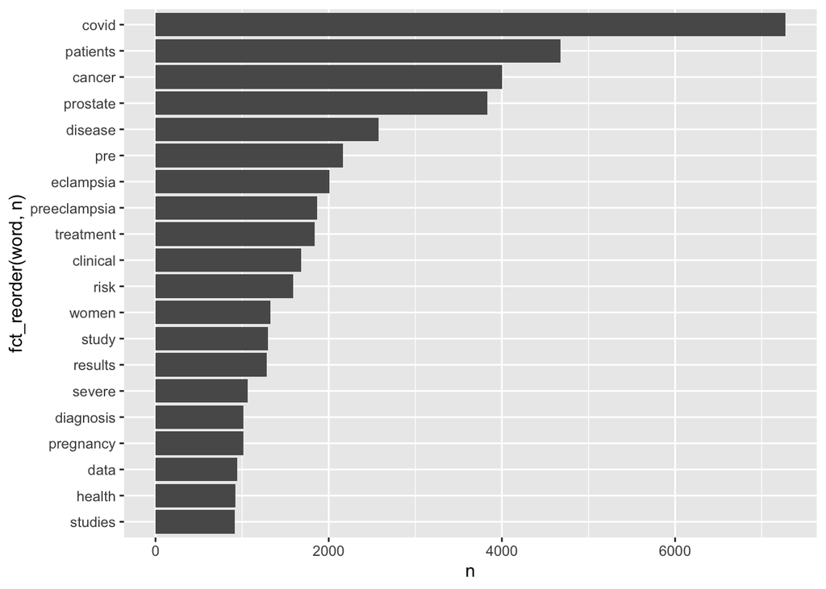

```r
library(stringr)
library(forcats)
number_words<-as.character(seq(0,100))

pubmed %>%
  unnest_tokens(output= word,input= abstract) %>%
  anti_join(tidytext :: stop_words, by="word") %>%
  filter (!(word %in% number_words)) %>%
  count( word, sort = TRUE) %>%
  top_n(20, n) %>%
  ggplot(aes(n, fct_reorder(word, n))) +
  geom_col()
```

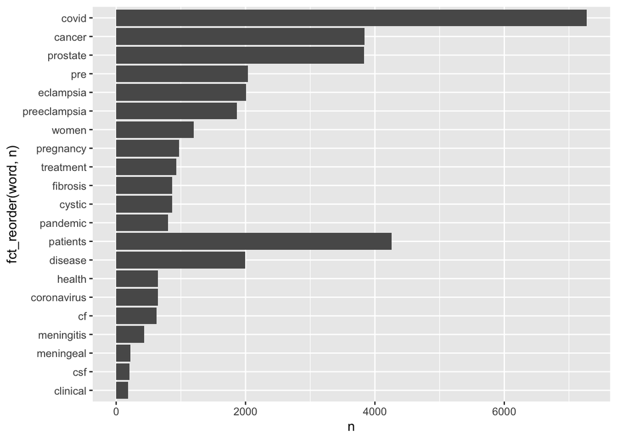

```r
number_words<-as.character(seq(0,100))

pubmed %>%
  unnest_tokens(output= word,input= abstract) %>%
  anti_join(tidytext :: stop_words, by="word") %>%
  filter (!(word %in% number_words)) %>%
  group_by(term) %>%
  count( word, sort = TRUE) %>%
  top_n(5, n) %>%
  ggplot(aes(n, fct_reorder(word, n))) +
  geom_col()
```

## Text_mining_2

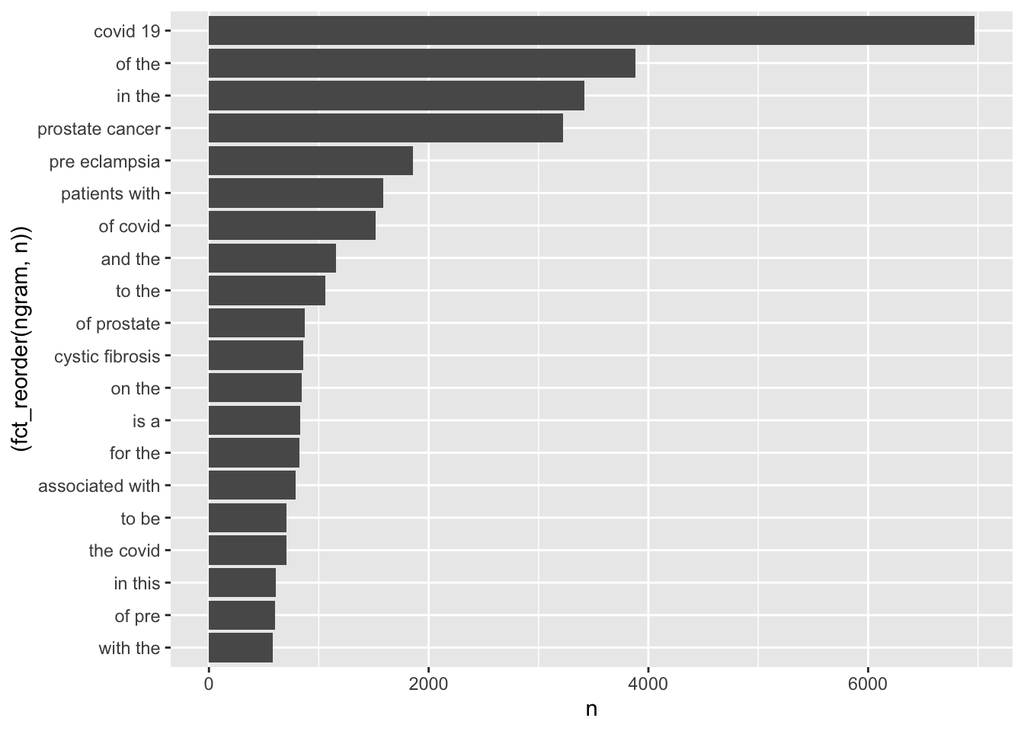

```r
pubmed %>%
  unnest_ngrams(output = ngram, input = abstract, n=2) %>%
  count(ngram, sort = TRUE) %>%
  top_n(20, n) %>%
  ggplot(aes(x=n, y=(fct_reorder(ngram, n)))) +
  geom_col()
```

## Text_mining_3

```r
pubmed %>%
  unnest_tokens(document, abstract) %>%
  count(document,term) %>%
  bind_tf_idf(document, term, n) %>%
  group_by(term) %>%
  arrange(desc(tf_idf))
```

```
## # A tibble: 39,240 x 6
## # Groups:   term [5]
##    document     term                n      tf   idf  tf_idf
##    <chr>        <chr>           <int>   <dbl> <dbl>   <dbl>
##  1 covid        covid            7275 0.0371  1.61  0.0597
##  2 prostate     prostate cancer  3832 0.0312  1.61  0.0502
##  3 eclampsia    preeclampsia     2005 0.0143  1.61  0.0230
##  4 preeclampsia preeclampsia     1863 0.0133  1.61  0.0214
##  5 meningitis   meningitis        429 0.00919 1.61  0.0148
##  6 cf           cystic fibrosis   625 0.0127  0.916 0.0117
##  7 fibrosis     cystic fibrosis   867 0.0176  0.511 0.00901
##  8 cystic       cystic fibrosis   862 0.0175  0.511 0.00896
##  9 meningeal    meningitis        219 0.00469 1.61  0.00755
## 10 pandemic     covid             800 0.00408 1.61  0.00657
## # … with 39,230 more rows
```

- Based off thr TF-IDF calculations: [covid] covid, coronavirus, pandemic, sars and cov [prostate cancer] prostate cancer, androgen, psa, prostatectomy, and castration [preclampsia] ecalampsia, preeclampsia, pregnancy, maternal, and gestational [meningitis] meningitis, meningeal, pachymeningitis, csf and meninges [cystic fibrosis]cf, fibrosis, cystis, cftr, and sweat

The results are different in that in the TF, we see that number of tokens connected in the document and in the method used in Q1 we see the overall count.